# R Notebook of studies into defining joint neuronal scATAC feature space for mouse CNS tissues E12-E15

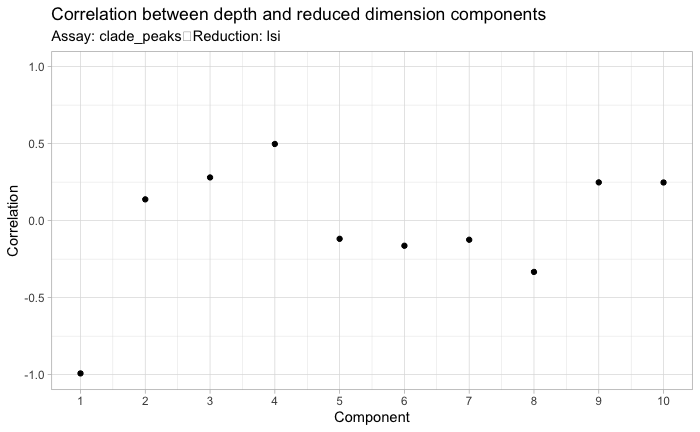

```r
DepthCor(neuronal.merged.filt)
```

```r
SVD.d <- neuronal.merged.filt@reductions$lsi@misc$d
SVD.u <- neuronal.merged.filt@reductions$lsi@misc$u
num.dimensions <- ncol(neuronal.merged.filt@reductions$lsi)
d_diagtsne = matrix(0, nrow=num.dimensions, ncol=num.dimensions)
diag(d_diagtsne) = SVD.d
# Assuming that first principle component is associated with read depth as shown above.
d_diagtsne[1,1] = 0
# Take approximate right singular vectors, matrix multiplication with singular values and transpose
SVDtsne_vd = t(d_diagtsne %*% t(SVD.u))

hclust_cells <- hclust(proxy::dist(SVDtsne_vd, method="cosine"), method="ward.D2")
hcd <- as.dendrogram(hclust_cells)
```

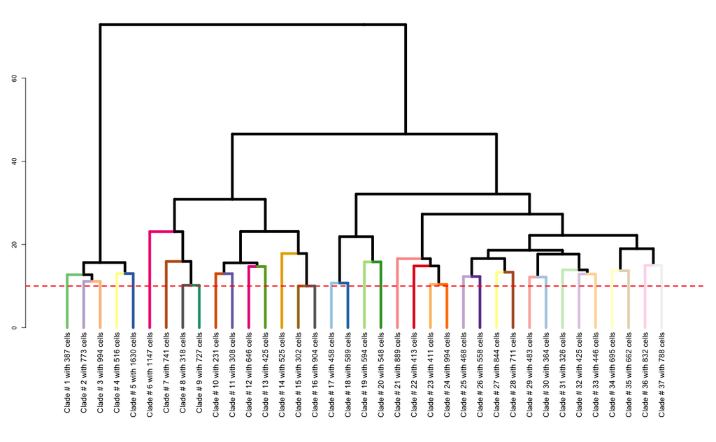

```r
par(mai=c(2,.5,.25,.25),cex=.75)
h = 10
hcd.cut <- cut(hcd, h = h)
hcd.upper<-hcd.cut$upper
hcd.upper.clusters<-cutree(hcd.upper,h=h)
hcd.upper<-reindex_dend(hcd.upper)
# Find out why this needs to be done, what is not reset in the object after cut but is reset after conversion back and worth
hcd.upper<-as.dendrogram(as.hclust(hcd.upper))
n.term.nodes <- sapply(hcd.cut$lower,count_terminal_nodes)
hcd.upper<-set_labels(hcd.upper,paste("Clade #",hcd.upper.clusters,"with",n.term.nodes,"cells",sep=" "))
color_branches(hcd.upper,clusters=hcd.upper.clusters,col=color.vector(hcd.upper.clusters)) %>% set("branches_lwd",5) %>% set("labels_cex",1.2) %>% plot(center=T)
abline(h = h, lty = 2, col="red", lwd=2)
```

```r
cells_tree_cut = cutree(hclust_cells, h=h)
lsi_cells = dplyr::tibble(barcode = Cells(neuronal.merged.filt), cells_tree_cut = cells_tree_cut)
```

```r
sample.clade
```

```
            1    2    3    4    5    6    7    8    9   10   11   12   13   14   15   16   17   18   19   20   21   22   23
  e12r1   306  452  761   74  199  714  176  240  302  188  203  252  235  204  135  186  208   10  299  124   42  111    1
  e14di     0    0    0   39   46  158  115  106    0    1    0    0    7  139  570   77   28   76   16    0  161    0  175
  e14vmb    0  148    4  205   33  109   53   47    0    2    2    0   44  150  160  118   59  354   36    2  285   16  264
  e14vr1  435  111    8  240  554  166  444  451    0  234  684  161  230  202  129  613  609   18  311  192 1142  199    6

           24   25   26   27   28   29   30   31   32   33   34   35   36   37
  e12r1     0    0    0    0    0    0    0    0    0    0    0    0    0    0
  e14di   548  336  592  375  480  420   82  645   63   36  387    2  308  231
  e14vmb    0   27    1   34    2    4  106    0  504  366    0   86    0    0
  e14vr1    0    1    1    2    1    1  539    1   22   66    0  437    0    0
```

Now main question is that what can we assume to be biological in terms of how cells are distributed in this table. Columns are now high level cellular clades with cut height of 10 (meaningful number only in the context of the hiearchical tree above) and numbers reflect how many cells from each sample are in which clades. We cannot entirely remove technical noise from affecting the clustering, though read depth has effect has been significantly reduced with priuor steps. Below same analysis with cut height of 9.

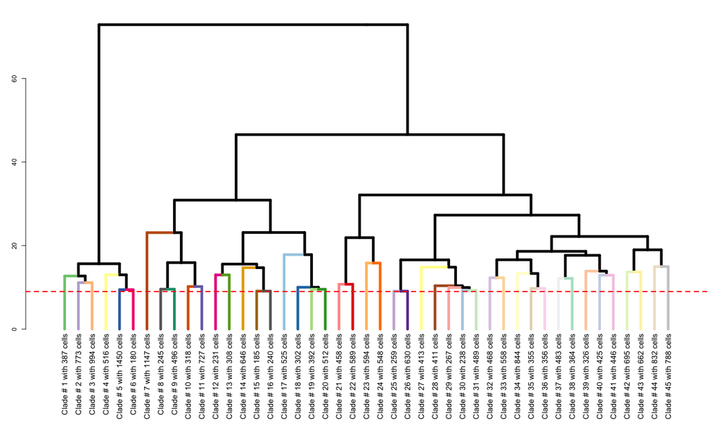

```r
par(mai=c(2,.5,.25,.25),cex=.75)
h = 9
hcd.cut <- cut(hcd, h = h)
hcd.upper<-hcd.cut$upper
hcd.upper.clusters<-cutree(hcd.upper,h=h)
hcd.upper<-reindex_dend(hcd.upper)
# Find out why this needs to be done, what is not reset in the object after cut but is reset after conversion back and worth
hcd.upper<-as.dendrogram(as.hclust(hcd.upper))
n.term.nodes <- sapply(hcd.cut$lower,count_terminal_nodes)
hcd.upper<-set_labels(hcd.upper,paste("Clade #",hcd.upper.clusters,"with",n.term.nodes,"cells",sep=" "))
color_branches(hcd.upper,clusters=hcd.upper.clusters,col=color.vector(hcd.upper.clusters)) %>% set("branches_lwd",5) %>% set("labels_cex",1.2) %>% plot(center=T)
abline(h = h, lty = 2, col="red", lwd=2)
```